# In Class Exercise 7

In this in class exercise, I will explore using igraph, tidygraph, ggraph and visNetworks on sample data to practice handling, processing, visualising and analysing social network data.

Jeremiah Lam https://sg.linkedin.com/in/jeremiah-lam-6156238a (School of Computing and Information Systems)https://scis.smu.edu.sg/  
2022-05-23

# Getting Started

Before getting started, it is important to ensure that the required R packages have been installed. If yes, we will load the R packages. If they have yet to be installed, we will install the R packages and load them onto R environment.

The chunk code below will do the trick.

```r
packages = c('igraph', 'tidygraph',
             'ggraph', 'visNetwork',
             'lubridate', 'clock',
             'tidyverse', 'ggmap')

for(p in packages){
  if(!require(p, character.only = T)){
    install.packages(p)
  }
  library(p, character.only = T)
}
```

# Importing the data

The code chunk below imports GAStech_email_node.csv from the data folder into R by using `read_csv()` of tidyverse package and saves it as a data frame called GAStech_nodes. Step is repeated for data/GAStech_email_edge-v2.csv.

After importing the data file into R, it is important for us to review the data object. We do this using `glimpse()`.

```r
GAStech_nodes <- read_csv("data/GAStech_email_node.csv")
GAStech_edges <- read_csv("data/GAStech_email_edge-v2.csv")

glimpse(GAStech_nodes)
```

```
Rows: 54
Columns: 4
$ id         <dbl> 1, 2, 3, 4, 5, 6, 7, 44, 45, 46, 8, 9, 10, 11, 12~
$ label      <chr> "Mat.Bramar", "Anda.Ribera", "Rachel.Pantanal", "~
$ Department <chr> "Administration", "Administration", "Administrati~
$ Title      <chr> "Assistant to CEO", "Assistant to CFO", "Assistan~
```

```r
glimpse(GAStech_edges)
```

```
Rows: 9,063
Columns: 8
$ source      <dbl> 43, 43, 44, 44, 44, 44, 44, 44, 44, 44, 44, 44, ~
$ target      <dbl> 41, 40, 51, 52, 53, 45, 44, 46, 48, 49, 47, 54, ~
$ SentDate    <chr> "6/1/2014", "6/1/2014", "6/1/2014", "6/1/2014", ~
$ SentTime    <time> 08:39:00, 08:39:00, 08:58:00, 08:58:00, 08:58:0~
$ Subject     <chr> "GT-SeismicProcessorPro Bug Report", "GT-Seismic~
$ MainSubject <chr> "Work related", "Work related", "Work related", ~
$ sourceLabel <chr> "Sven.Flecha", "Sven.Flecha", "Kanon.Herrero", "~
$ targetLabel <chr> "Isak.Baza", "Lucas.Alcazar", "Felix.Resumir", "~
```

# Prepping the data

To get the Sentdate in proper day, month, year format using `dmy()` and get the weekday.

```r
GAStech_edges <- GAStech_edges %>%
  mutate(SentDate = dmy(SentDate)) %>%
  mutate(Weekday = weekdays(SentDate))
```

## Wrangling attribute

```r
GAStech_edges_agg <- GAStech_edges %>%
  filter(MainSubject == "Work related") %>%
  group_by(source, target, Weekday) %>%
  summarise(Weight = n()) %>%
  filter(source!=target) %>%
  filter(Weight > 1) %>%
  ungroup
```

# Building graph model

```r
GAStech_graph <- tbl_graph(nodes = GAStech_nodes,
                           edges = GAStech_edges_agg,
                           directed = TRUE)

GAStech_graph
```

```
# A tbl_graph: 54 nodes and 1456 edges
#
# A directed multigraph with 1 component
#
# Node Data: 54 x 4 (active)
     id label               Department     Title
  <dbl> <chr>               <chr>          <chr>
1     1 Mat.Bramar          Administration Assistant to CEO
2     2 Anda.Ribera         Administration Assistant to CFO
3     3 Rachel.Pantanal     Administration Assistant to CIO
4     4 Linda.Lagos         Administration Assistant to COO
5     5 Ruscella.Mies.Haber Administration Assistant to Engineering G~
6     6 Carla.Forluniau     Administration Assistant to IT Group Mana~
# ... with 48 more rows
#
# Edge Data: 1,456 x 4
   from    to Weekday Weight
  <int> <int> <chr>    <int>
1     1     2 Friday       8
2     1     2 Monday       4
3     1     2 Tuesday      3
# ... with 1,453 more rows
```

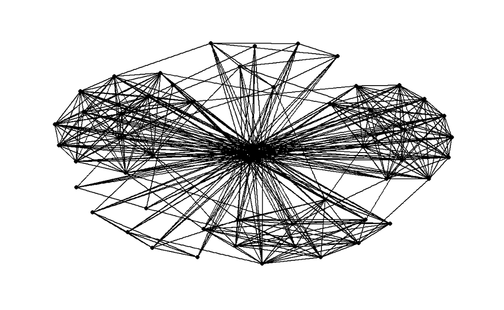

```r
ggraph(GAStech_graph,
       layout = "stress") +
  geom_edge_link() +
  geom_node_point() +
  theme_graph()
```

## Modifying the nodes

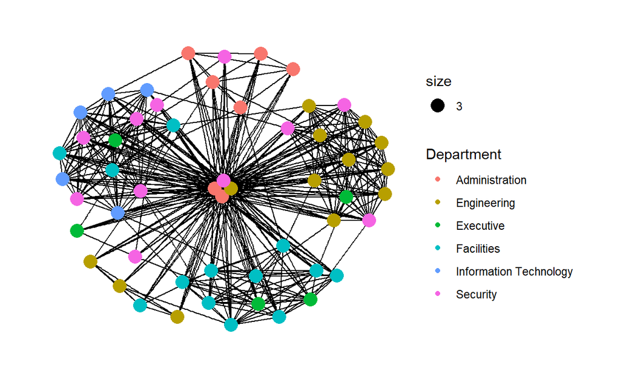

```r
ggraph(GAStech_graph,
       layout = "stress") +
  geom_edge_link() +
  geom_node_point(aes(color = Department,
                      size = 3)) +
  theme_graph()
```

## Modifying the Edges

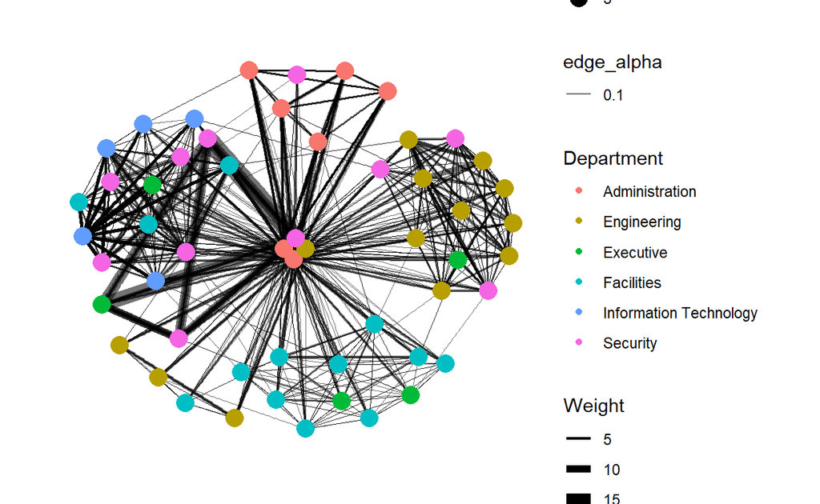

```r
ggraph(GAStech_graph,
       layout = "stress") +
  geom_edge_link(aes(width = Weight,
                     alpha = 0.1
                     )) +
  scale_edge_width(range = c(0.1, 5)) +
  geom_node_point(aes(color = Department,
                      size = 3)) +
  theme_graph()
```

## Working with facet edges

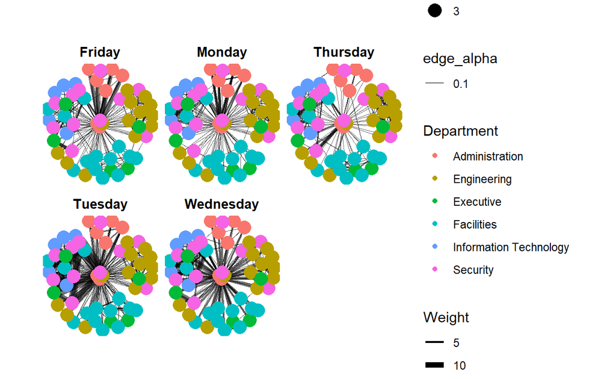

```r
ggraph(GAStech_graph,
       layout = "stress") +
  geom_edge_link(aes(width = Weight,
                     alpha = 0.1
                     )) +
  scale_edge_width(range = c(0.1, 5)) +
  geom_node_point(aes(color = Department,
                      size = 3)) +
  theme_graph() +
  facet_edges(~Weekday)
```

## Working with facet node

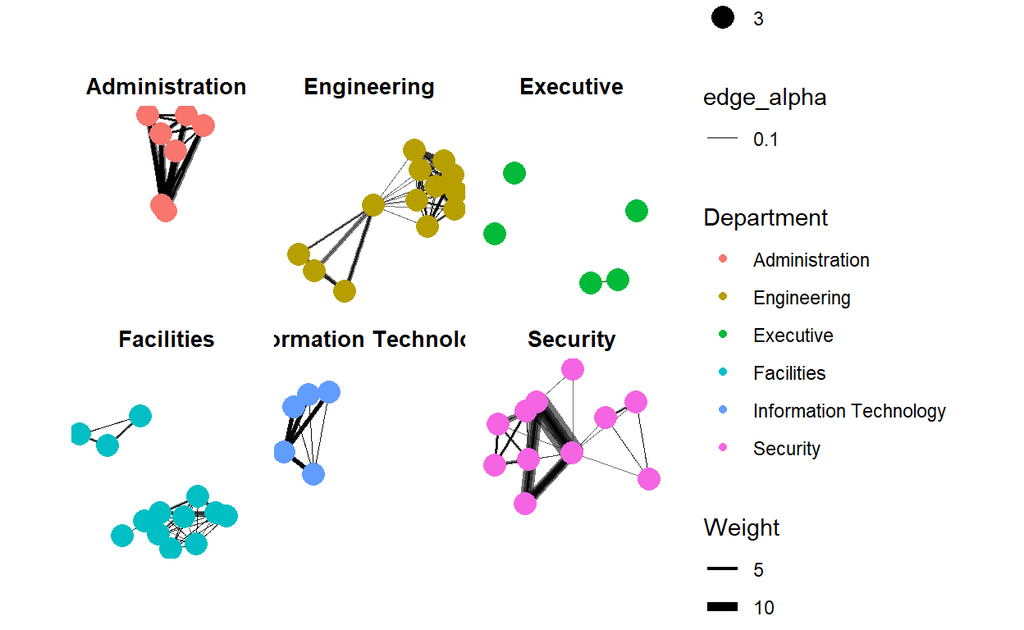

```r
ggraph(GAStech_graph,
       layout = "stress") +
  geom_edge_link(aes(width = Weight,
                     alpha = 0.1
                     )) +
  scale_edge_width(range = c(0.1, 5)) +
  geom_node_point(aes(color = Department,
                      size = 3)) +
  theme_graph() +
  facet_nodes(~Department)
```

## Network Metrics Analysis

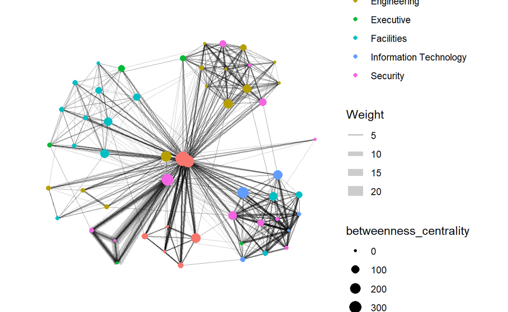

```r
g <- GAStech_graph %>%
  mutate(betweenness_centrality = centrality_betweenness()) %>%
  ggraph(layout = "fr") +
  geom_edge_link(aes(width=Weight),
                 alpha=0.2) +
  scale_edge_width(range = c(0.1, 5)) +
  geom_node_point(aes(colour = Department,
            size=betweenness_centrality))
g + theme_graph()
```

# Data preparation for visNetwork

```r
GAStech_edges_aggregated <- GAStech_edges %>%
  left_join(GAStech_nodes, by = c("sourceLabel" = "label")) %>%
  rename(from = id) %>%
  left_join(GAStech_nodes, by = c("targetLabel" = "label")) %>%
  rename(to = id) %>%
  filter(MainSubject == "Work related") %>%
  group_by(from, to) %>%
    summarise(weight = n()) %>%
  filter(from!=to) %>%
  filter(weight > 1) %>%
  ungroup()
```

# Plotting interactive netowrk graph via visNetwork

```r
visNetwork(GAStech_nodes,
           GAStech_edges_aggregated)
```

[interactive chart not shown]

## Using Fruchterman and Reingold layout

```r
visNetwork(GAStech_nodes,
           GAStech_edges_aggregated) %>%
  visIgraphLayout(layout = "layout_with_fr")
```

[interactive chart not shown]

## Highlighting the nodes

```r
GAStech_nodes2 <- GAStech_nodes %>%
  rename(group = Department)
```

```r
visNetwork(GAStech_nodes2,
           GAStech_edges_aggregated) %>%
  visIgraphLayout(layout = "layout_with_fr") %>%
  visLegend() %>%
  visLayout(randomSeed = 123)
```

[interactive chart not shown]

## Improving the edges

```r
visNetwork(GAStech_nodes2,
           GAStech_edges_aggregated) %>%
  visIgraphLayout(layout = "layout_with_fr") %>%
  visEdges(arrows = "to",
           smooth = list(enabled = TRUE,
                         type = "curvedCW")) %>%
  visLegend() %>%
  visLayout(randomSeed = 123)
```

[interactive chart not shown]

## Giving it interactivity

```r
visNetwork(GAStech_nodes2,
           GAStech_edges_aggregated) %>%
  visIgraphLayout(layout = "layout_with_fr") %>%
  visOptions(highlightNearest = TRUE,
             nodesIdSelection = TRUE) %>%
  visLegend() %>%
  visLayout(randomSeed = 123)
```

[interactive chart not shown]